# Analyzing Targeted Bisulfite Sequencing data with SOMNiBUS

Kaiqiong Zhao

Department of Epidemiology, Biostatistics and Occupational Health, McGill University, Montreal, Canada

21 July 2020

# 1 Introduction

**SOMNiBUS** aims to analyze count-based methylation data on predefined genomic regions, such as those obtained by targeted sequencing, and thus to identify differentially methylated regions (DMRs) that are associated with phenotypes or traits.

Major advantages of **SOMNiBUS**

- Take account of experimental errors
- Allow for multiple covariates, such as proportions of different cell types.
- Enable estimating smooth covariate effects and assessing statistical significance of methylation regions

For a more comprehensive introduction of the **SOMNiBUS** approach, please read our SOMNiBUS paper (Kaiqiong Zhao 2020).

## 1.1 Installation

Currently, the software package can be installed from [github](https://github.com/kaiqiong/SOMNiBUS).

## 1.2 Dependencies

```r
library(SOMNiBUS)
```

## 1.3 System Requirements

## 1.4 Citation

If you use this package, please cite our SOMNiBUS paper (Kaiqiong Zhao 2020).

# 2 Data example

Throughout this vignette, we illustrate the **SOMNiBUS** approach with analysis of a targeted region from a rheumatoid arthritis (RA) study. See `help(RAdat)` for further details. In this example, the phenotype of major interest is the RA status (coded as `RA`) and the adjusting variable is the cell type status (coded as `T_cell`) which is binary because the experiment used cell-type-separated blood samples, and methylation profiles were characterized for both T-cells and Monocytes. We will refer to both `RA` and `T_cell` as *covariates*. We are going to use the package `SOMNiBUS` to investigate the methylation patterns in this region and study association with RA status and cell type.

```r
data(RAdat)
```

# 3 Input data

Currently, we require a matrix-type input of the methylated reads (`Meth_Counts`) and the read depth (`Total_Counts`) for CpG sites of each sample. Inputs in another other format, such as Bismark or a `BSeq` object from the **bsseq** package, will be incorporated in the future.

Before using the package, the input data matrix (or data frame) should be formatted such that:

1. each row represents a CpG site
2. the first 4 columns should contain the information of `Meth_Counts` (methylated counts), `Total_Counts` (read depths), `Position` (Genomic position for the CpG site) and `ID` (sample ID)
3. the covariate(s), such as disease status or cell type composition are listed in column 5 and onwards.

An example of the input data:

```r
head(RAdat)
```

```
#>   Meth_Counts Total_Counts  Position ID T_cell RA
#> 1           0            8 102711629  1      0  1
#> 2           0            2 102711630  1      0  1
#> 3           0           12 102711702  1      0  1
#> 4           0            4 102711703  1      0  1
#> 5           0           15 102711747  1      0  1
#> 6           0            6 102711748  1      0  1
```

## 3.1 Filtering CpGs and samples

To better use the information in the methylation dataset, on one hand, **SOMNiBUS** uses a smoothing technique (regression splines) to borrow information from the nearby CpG sites; on the other hand, our approach uses regression-based modelling to take advantage of information contained across samples. Therefore, this algorithm does not require filtering out the CpG sites that have methylation levels measured only in a small part of the samples, or the samples that have overall poor read-depths and many missing values. Our analysis of differentially methylated regions (DMRs) requires filtering only on the following two conditions:

- individual CpGs that have zero reads in a particular sample
- samples that have missing values in any of the covariates of interest (i.e missing values for `T_cell` or `RA` in the data set `RAdat`)

```r
RAdat.f <- na.omit(RAdat[RAdat$Total_Counts != 0, ])
```

## 3.2 Adjusting for covariates and adding interactions

- we currently only accept numeric input for the covariates used to fit the model. we recommend that first transform your categorical variables into appropriate dummy variables
- interaction terms can be added in the analysis model. To do that, the program requires that users add another column of covariate values into the input data set calculated as the product of two existing covariates whose interaction is of interest.

# 4 Analysis

The smooth covariate estimation and the region-wise test steps are wrapped into a function `binomRegMethModel`. See `help(binomRegMethModel)` for more details. We can use the following code to run the analysis with both covariates `T_cell` and `RA`.

```r
out <- binomRegMethModel(data = RAdat.f, n.k = rep(5, 3), p0 = 0.003, p1 = 0.9, Quasi = FALSE, RanEff = FALSE)
```

Or, we can use the argument `covs` to specify that we only want the covariate `T_cell` in the model.

```r
out.ctype <- binomRegMethModel(data = RAdat.f, n.k = rep(5, 3), p0 = 0.003, p1 = 0.9, covs = "T_cell")
```

## 4.1 Error rates $p_0$ and $p_1$

In the example data set, we have cell type separated samples. The error rates for individual samples can be estimated by a E-M algorithm (Lakhal-Chaieb et al. 2017) using the package `SmoothMSC`. The error rate default values, $p_0=0.003$ and $p_1=0.9$, were estimated as the average incomplete ($p_0$) or over- conversion ($1-p_1$). These two estimated values coincide roughly with the incomplete and over conversion rates in a bisulfite sequencing experiment reported in Prochenka et al. (2015).

For experiments with samples from a tissue containing a mixture of cell types, the user could consider the following ways to specify the error rates $p_0$ and $1-p_1$.

- If users have conducted experiments for measuring error/conversion rates, such as adding spike-in sequences of DNA that are known in advance to be methylated or unmethylated into the bisulfite sequencing procedure, they can use the measured error rates for the input of `p0` and `p1`
- One can also use the error rates (incomplete and over conversion rates) that have been previous reported in the literature.
- Another option is to use our default values.

## 4.2 Basis dimensions: `n.k`:

Argument `n.k` in the `binomRegMethModel` is the dimension of the basis expansion for smooth covariate effects. The exact number `n.k` used for each functional parameter is not crucial, because it only sets an upper bound. We recommend choosing a basis dimension approximately equal to the number of unique CpGs in the region divided by 20.

# 5 Results

## 5.1 Result from the region-wide test of zero effect of all covariates:

```r
out$reg.out
```

```
#>                EDF    Chi.sq       p-value
#> Intercept 3.999034 584.06810 2.366352e-125
#> T_cell    2.007277 999.31851 1.763330e-217
#> RA        3.903903  80.44909  2.116877e-16
```

## 5.2 Estimation of the smooth covariate effects

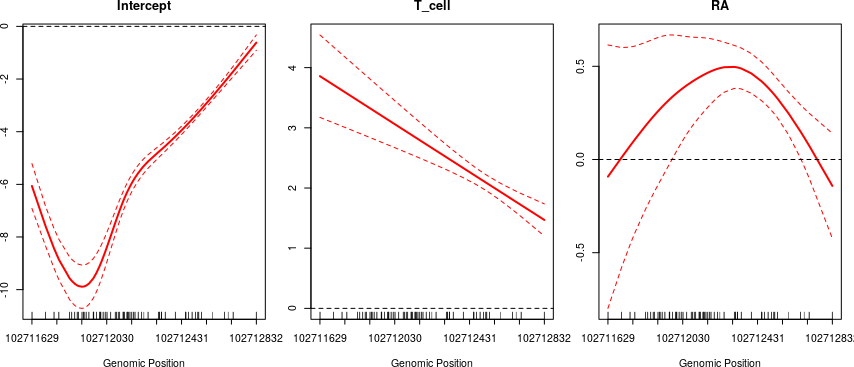

Figure 1: The estimates (solid red lines) and 95% pointwise confidence intervals (dashed red lines) of the intercept, the smooth effect of cell type and RA on methylation levels

```r
binomRegMethModelPlot(out)
```

We can also force the covariate effect plots to have the same vertical range, for all covariates, by specifying `same.range= T`.

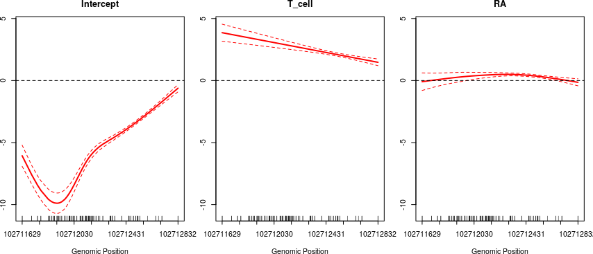

Figure 2: The estimates (solid red lines) and 95% pointwise confidence intervals (dashed red lines) of the intercept, the smooth effect of cell type and RA on methylation levels  
(Same ranges of Y axis.)

```r
binomRegMethModelPlot(out, same.range = TRUE)
```

## 5.3 Predicted methylation levels

First, construct a new data set for prediction. Make sure that the Position in the new data set is the same as the original input `data` in `binomRegMethModel`.

```r
pos <- out$uni.pos
my.p <- length(pos)
newdata <- expand.grid(pos, c(0, 1), c(0, 1))
colnames(newdata) <- c("Position", "T_cell", "RA")
```

The predicted methylation levels can be calculated from function `binomRegMethModelPred`

```r
my.pred <- binomRegMethModelPred(out, newdata, type = "link.scale")
```

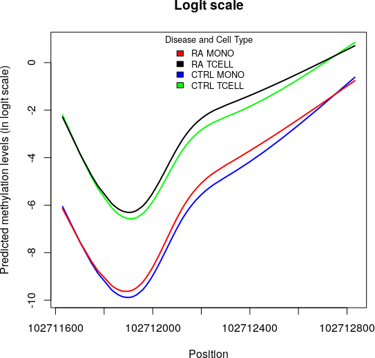

Figure 3: The predicted methylation levels in the logit scale for the 4 groups of samples with different disease and cell type status

```r
plot(pos[order(pos)], (my.pred[(newdata$RA == 0 & newdata$T_cell == 0)])[order(pos)],
  type = "l", xlab = "Position",
  ylab = "Predicted methylation levels (in logit scale)", col = "blue", main = "Logit scale", ylim = c(min(my.pred), max(my.pred)), lwd = 2
)
lines(pos[order(pos)], (my.pred[(newdata$RA == 0 & newdata$T_cell == 1)])[order(pos)],
  type = "l", xlab = "Position",
  ylab = "predicted", col = "green", lwd = 2
)
lines(pos[order(pos)], (my.pred[(newdata$RA == 1 & newdata$T_cell == 0)])[order(pos)],
  type = "l", xlab = "Position",
  ylab = "predicted", col = "red", lwd = 2
)
lines(pos[order(pos)], (my.pred[(newdata$RA == 1 & newdata$T_cell == 1)])[order(pos)],
  type = "l", xlab = "Position",
  ylab = "predicted", col = "black", lwd = 2
)
legend("top", c("RA MONO", "RA TCELL", "CTRL MONO", "CTRL TCELL"),
  fill = c("red", "black", "blue", "green"),
  title = "Disease and Cell Type", bty = "n", cex = 0.8
)
```

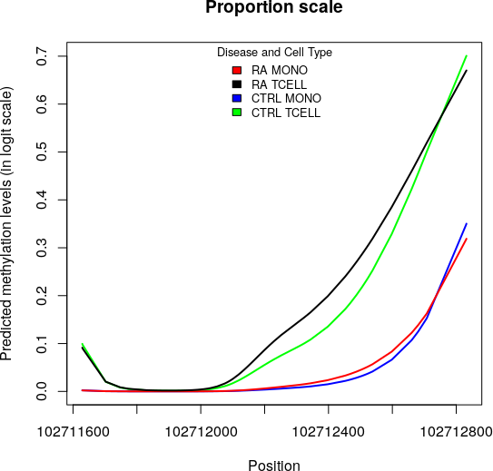

Figure 4: The predicted methylation levels proportion scale (right) for the 4 groups of samples with different disease and cell type status

```r
my.pred <- binomRegMethModelPred(out, newdata, type = "proportion")
plot(pos[order(pos)], (my.pred[(newdata$RA == 0 & newdata$T_cell == 0)])[order(pos)],
  type = "l", xlab = "Position",
  ylab = "Predicted methylation levels (in logit scale)", col = "blue", main = "Proportion scale", ylim = c(min(my.pred), max(my.pred)), lwd = 2
)
lines(pos[order(pos)], (my.pred[(newdata$RA == 0 & newdata$T_cell == 1)])[order(pos)],
  type = "l", xlab = "Position",
  ylab = "predicted", col = "green", lwd = 2
)
lines(pos[order(pos)], (my.pred[(newdata$RA == 1 & newdata$T_cell == 0)])[order(pos)],
  type = "l", xlab = "Position",
  ylab = "predicted", col = "red", lwd = 2
)
lines(pos[order(pos)], (my.pred[(newdata$RA == 1 & newdata$T_cell == 1)])[order(pos)],
  type = "l", xlab = "Position",
  ylab = "predicted", col = "black", lwd = 2
)
legend("top", c("RA MONO", "RA TCELL", "CTRL MONO", "CTRL TCELL"),
  fill = c("red", "black", "blue", "green"),
  title = "Disease and Cell Type", bty = "n", cex = 0.8
)
```

# 6 An example requiring short runtime

In this example, `RAdat` was analyzed. There are 43 samples and 2 binary covariate of interest. The region under investigation consists of 123 CpG sites.

```r
RAdat.f <- na.omit(RAdat[RAdat$Total_Counts != 0, ])
```

```r
time0 <- Sys.time()
out_quasi <- binomRegMethModel(data = RAdat.f, n.k = rep(5, 3), p0 = 0.003, p1 = 0.9, Quasi = TRUE, RanEff = FALSE)
print(Sys.time() - time0)
```

```
#> Time difference of 25.67626 secs
```

```r
out_quasi$reg.out
```

```
#>                EDF         F       p-value
#> Intercept 3.998884 120.37877 6.323439e-100
#> T_cell    2.006039 408.79080 4.394429e-172
#> RA        3.830306  17.14922  3.363169e-13
```

# 7 An example requiring longer runtime

Here, a relative larger data set `RAdat2` with 9 covariates is used for illustration. In `RAdat2`, methylation levels on a region with 208 CpGs for 116 blood samples are available.

```r
data("RAdat2")
head(RAdat2)
```

```
#>    Meth_Counts Total_Counts Position ID ACPA4   Age Sex Smoking Smoking_NA
#> 48           0            8 24713943  1     0 65.58   2       0          1
#> 49           0            8 24713954  1     0 65.58   2       0          1
#> 50           0            8 24713956  1     0 65.58   2       0          1
#> 51           0            8 24713964  1     0 65.58   2       0          1
#> 52           0            8 24713968  1     0 65.58   2       0          1
#> 53           0            8 24713976  1     0 65.58   2       0          1
#>          PC1      PC2        PC3         PC4
#> 48 -2.052637 0.648359 -0.3340604 0.007593961
#> 49 -2.052637 0.648359 -0.3340604 0.007593961
#> 50 -2.052637 0.648359 -0.3340604 0.007593961
#> 51 -2.052637 0.648359 -0.3340604 0.007593961
#> 52 -2.052637 0.648359 -0.3340604 0.007593961
#> 53 -2.052637 0.648359 -0.3340604 0.007593961
```

```r
nCpG <- length(unique(RAdat2$Position))
time0 <- Sys.time()
out_RA2 <- binomRegMethModel(data = RAdat2, n.k = c(5, rep(max(3, round(nCpG / 20)), 9)), p0 = 0.003, p1 = 0.9, Quasi = TRUE, RanEff = FALSE)
print(Sys.time() - time0)
```

```
#> Time difference of 3.469417 mins
```

```r
out_RA2$reg.out
```

```
#>                 EDF          F      p-value
#> Intercept  2.032529  1.9151600 1.682402e-01
#> ACPA4      2.000479  0.8673164 4.201375e-01
#> Age        5.503425 24.5804993 8.729739e-26
#> Sex        2.724631  2.3355247 1.487421e-01
#> Smoking    2.977477  0.8841536 4.535045e-01
#> Smoking_NA 2.000607  3.9688144 1.893494e-02
#> PC1        2.000588 13.3876397 1.574100e-06
#> PC2        2.000507  0.8562235 4.248488e-01
#> PC3        2.001114  2.6764358 6.882849e-02
#> PC4        2.000420  1.4600641 2.322975e-01
```

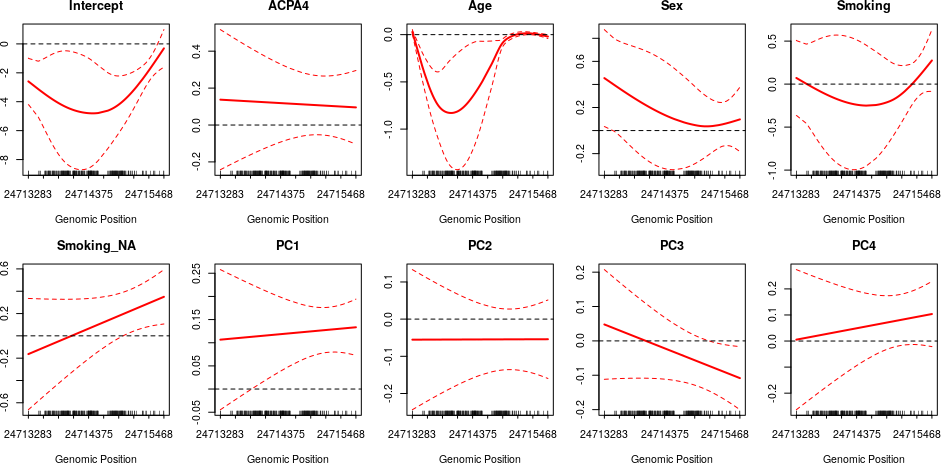

```r
binomRegMethModelPlot(out_RA2, mfrow = c(2, 5))
```

## 7.1 No error

We can also specify no error

```r
time0 <- Sys.time()
out_RA2_noError <- binomRegMethModel(data = RAdat2, n.k = c(5, rep(max(3, round(nCpG / 20)), 9)), p0 = 0, p1 = 1, Quasi = TRUE, RanEff = FALSE)
print(Sys.time() - time0)
```

```
#> Time difference of 39.08917 secs
```

```r
out_RA2_noError$reg.out
```

```
#>                 EDF          F      p-value
#> Intercept  3.307081  4.3094331 3.647787e-03
#> ACPA4      6.418254  0.7314243 6.056072e-01
#> Age        9.951585 11.9428903 8.669859e-21
#> Sex        5.356565  2.2717209 4.003367e-02
#> Smoking    4.011761  0.9004142 4.630143e-01
#> Smoking_NA 4.889146  2.2350236 4.156897e-02
#> PC1        2.003669 13.0605676 2.158537e-06
#> PC2        5.306235  1.6394702 1.458101e-01
#> PC3        7.837912  1.3403299 2.089695e-01
#> PC4        6.567736  1.1344201 3.490422e-01
```

# References

Kaiqiong Zhao, Lajmi Lakhal‐Chaieb, Karim Oualkacha. 2020. “A Novel Statistical Method for Modeling Covariate Effects in Bisulfite Sequencing Derived Measures of Dna Methylation.” *Journal of the International Biometric Society*. Wiley Periodicals, Inc. https://doi.org/10.1111/biom.13307.

Lakhal-Chaieb, Lajmi, Celia MT Greenwood, Mohamed Ouhourane, Kaiqiong Zhao, Belkacem Abdous, and Karim Oualkacha. 2017. “A Smoothed Em-Algorithm for Dna Methylation Profiles from Sequencing-Based Methods in Cell Lines or for a Single Cell Type.” *Statistical Applications in Genetics and Molecular Biology* 16 (5-6). De Gruyter: 333–47.

Prochenka, Agnieszka, Piotr Pokarowski, Piotr Gasperowicz, Joanna Kosińska, Piotr Stawiński, Renata Zbieć-Piekarska, Magdalena Spólnicka, Wojciech Branicki, and Rafał Płoski. 2015. “A Cautionary Note on Using Binary Calls for Analysis of Dna Methylation.” *Bioinformatics* 31 (9). Oxford University Press: 1519–20.